## Apprentissage par renforcement

**Théorie :**

- Deep Q-learning (DQN)
- Memory replay

**Exercices :**

- Cart-Pole

### Deep Q-learning (DQN)

Le deep Q-learning est l'association entre le deep-learning et du renforcement en Q-learning. C'est le rôle du réseau de généraliser la valeur Q au sein d'états similaires. L'état peut être un ensemble de caractéristiques "hand-crafted", ou directement l'image RGB du jeu.  
Nous allons utiliser la libraire ["gym"](https://gym.openai.com) pour nos expériences. La première consistera à trouver une bonne politique pour le jeu du CartPole :

[figure not shown]

Le jeu est [défini comme suit](https://gym.openai.com/envs/CartPole-v1/) :

> A pole is attached by an un-actuated joint to a cart, which moves along a frictionless track. The system is controlled by applying a force of +1 or -1 to the cart. The pendulum starts upright, and the goal is to prevent it from falling over. A reward of +1 is provided for every timestep that the pole remains upright. The episode ends when the pole is more than 15 degrees from vertical, or the cart moves more than 2.4 units from the center.

[video not shown]

[Dans le code source disponible](https://github.com/openai/gym/blob/master/gym/envs/classic_control/cartpole.py), on peut avoir des informations sur l'environement :

```python
"""
    Description:
        A pole is attached by an un-actuated joint to a cart, which moves along a frictionless track. The pendulum starts upright, and the goal is to prevent it from falling over by increasing and reducing the cart's velocity.
    Source:
        This environment corresponds to the version of the cart-pole problem described by Barto, Sutton, and Anderson
    Observation:
        Type: Box(4)
        Num	Observation                 Min         Max
        0	Cart Position             -4.8            4.8
        1	Cart Velocity             -Inf            Inf
        2	Pole Angle                 -24 deg        24 deg
        3	Pole Velocity At Tip      -Inf            Inf

    Actions:
        Type: Discrete(2)
        Num	Action
        0	Push cart to the left
        1	Push cart to the right

        Note: The amount the velocity that is reduced or increased is not fixed; it depends on the angle the pole is pointing. This is because the center of gravity of the pole increases the amount of energy needed to move the cart underneath it
    Reward:
        Reward is 1 for every step taken, including the termination step
    Starting State:
        All observations are assigned a uniform random value in [-0.05..0.05]
    Episode Termination:
        Pole Angle is more than 12 degrees
        Cart Position is more than 2.4 (center of the cart reaches the edge of the display)
        Episode length is greater than 200
        Solved Requirements
        Considered solved when the average reward is greater than or equal to 195.0 over 100 consecutive trials.
    """
```

Un état $s$ est de taille $4$ et l'espace des actions $A$ vaut 2. Nous pourrions donc définir un réseau de neurones qui aurait cette structure :

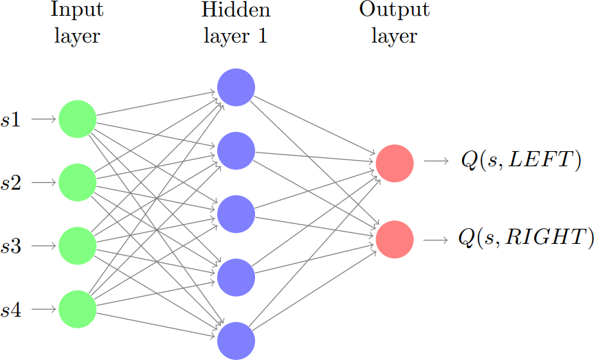

On peut mettre à jour le réseau traitant la formule Q-learning de la section précédente comme un problème de régression : $$loss = \underbrace{r_{t} +\gamma \cdot \max_{a}Q(s_{t+1}, a)}_{\text{target}} - \underbrace{Q(s_{t},a_{t}}_{\text{prediction}})$$ Jusqu'ici : rien de révolutionnaire. Pourquoi a-t-il fallu attendre 2015 pour que le deep q-learning [soit proposé par Google DeepMind](https://www.cs.toronto.edu/~vmnih/docs/dqn.pdf) ?

### Memory replay

**Le fait est que les réseaux de neurones ne sont pas originalement pensés pour aborder des problèmes de renforcement** et ce pour deux raisons majeures :

- Les données d'un épisode de renforcement sont **hautement corrélées**
- La distribution des différents épisodes est **non-stationnaire**

Nous avons vu dans l'apprentissage supervisé que les données sont non-corrélées : un classifieur d'animaux verra plein de chats différents et donc non-corrélés. Egalement, la prédiction pour une image n'affecte (normalement) pas directement la prochaine prédiction. En renforcement, dire à pacman d'aller à droite ne change que très peu le contenu de l'état : pacman a faiblement bougé, tout comme les fantômes, les boules sont toujours à la même place, le score n'a pas changé,... : les données sont hautement corrélées. Cependant, cette décision d'aller à droite influe hautement l'issue de la partie : une mauvaise action telle que se rapprocher d'un fantôme peut être fatale. La série temporelle de décisions a donc un fort impact sur la structure du problème, ce qui le rend non-stationnaire.  
Pour palier à ces deux propriétés, nous devons introduire la "mémoire replay". Chaque tuple (qui consiste selon la formule à un état $s$, une action $a$, une reward $r$, et un prochain état $s^{\prime}$) que l'agent expérience sera stockée dans une mémoire. Au lieu d'entrainer un réseau de neurones de manière séquentielle (et donc corrélé), un batch d'exemples sera formé selon un échantillonage aléatoire parmi toutes les expériences disponibles dans la mémoire. Adopter cette stratégie à trois effets :

- Efficacité computationelle de l'entraînement;
- Dé-corrélation des données;
- Moyennation de la distribution des données;

### Cart-Pole

```python
!apt-get install -y xvfb python-opengl > /dev/null 2>&1
!pip install gym pyvirtualdisplay > /dev/null 2>&1
!apt-get install x11-utils > /dev/null 2>&1
!pip install pyglet==1.3.2 > /dev/null 2>&1
```

```python
import gym
import random
import torch
import numpy as np
from collections import deque
import matplotlib.pyplot as plt
%matplotlib inline
```

Complétez le réseau de neurones qui approximera la politique $\pi$. Dans le $init$, vous devez déclarer les trois couches. Dans le $forward$, il vous faudra faire passer l'état donné en paramètre de la méthode pour en sortir les valeurs $Q$.

```python
import torch
import torch.nn as nn
import torch.nn.functional as F

class QNetwork(nn.Module):
    """Actor (Policy) Model."""

    def __init__(self, state_size, action_size, seed, fc1_units=64, fc2_units=64):
        """Initialize parameters and build model.
        Params
        ======
            state_size (int): Dimension of each state
            action_size (int): Dimension of each action
            seed (int): Random seed
            fc1_units (int): Number of nodes in first hidden layer
            fc2_units (int): Number of nodes in second hidden layer
        """
        super(QNetwork, self).__init__()
        self.seed = torch.manual_seed(seed)
        # COMPLETER : DEFINIR TROIS COUCHES :
        # h1: un fully connected qui mappe l'état vers une dimension 64
        # h2: un fully connected qui mappe h1 vers une nouvelle dimension 64
        # o : un fully connected qui mappe h2 vers une sortie de taille action_size


    def forward(self, state):
        """Build a network that maps state -> action values."""
        # A compléter
        # forward pass de l'état state
```

Le code ci-dessous déclare la mémoire replay, elle est déjà complétée. Nous voyons que son implémentation est triviale.

```python
class ReplayBuffer:
    """Fixed-size buffer to store experience tuples."""

    def __init__(self, buffer_size, batch_size, seed):
        """Initialize a ReplayBuffer object.
        Params
        ======
            buffer_size (int): maximum size of buffer
            batch_size (int): size of each training batch
            seed (int): random seed
        """
        self.action_size = actin_size
        self.memory = deque(maxlen=buffer_size)
        self.batch_size = batch_size
        self.experience = namedtuple("Experience", field_names=["state", "action", "reward", "next_state", "done"])
        self.seed = random.seed(seed)

    def add(self, state, action, reward, next_state, done):
        """Add a new experience to memory."""
        e = self.experience(state, action, reward, next_state, done)
        self.memory.append(e)

    def sample(self):
        """Randomly sample a batch of experiences from memory."""
        experiences = random.sample(self.memory, k=self.batch_size)

        states = torch.from_numpy(np.vstack([e.state for e in experiences if e is not None])).float().to(device)
        actions = torch.from_numpy(np.vstack([e.action for e in experiences if e is not None])).long().to(device)
        rewards = torch.from_numpy(np.vstack([e.reward for e in experiences if e is not None])).float().to(device)
        next_states = torch.from_numpy(np.vstack([e.next_state for e in experiences if e is not None])).float().to(device)
        dones = torch.from_numpy(np.vstack([e.done for e in experiences if e is not None]).astype(np.uint8)).float().to(device)

        return (states, actions, rewards, next_states, dones)

    def __len__(self):
        """Return the current size of internal memory."""
        return len(self.memory)
```

Le code ci-dessous est le plus important : il définit l'agent qui possède deux attributs : un réseau de neurones pour prendre ses décisions, et une mémoire replay. Il dispose également de trois fonctions :

- La méthode $act()$ : retourne l'action selon la politique courante définie par le réseau pour l'état "state" (toujours selon le dilemme exploration-exploitation). Cette fonction est intéressante pour peupler la mémoire replay de quadruples $(s, r, a, s^{\prime})$. **Notez que le réseau passe en mode évaluation et on ne requiert pas de gradient pour cette fonction car elle n'est pas utilisée comme processus d'apprentissage**;
- La méthode $step()$ : remplit la mémoire replay et forme des batches via la mémoire replay quand celle-ci est assez peuplée;
- La méthode $learn()$ : met à jour la politique de décisions en mettant à jour le réseau de neurones selon les quadruples "expériences" donnés en paramètres.

Remplissez les fonctions concernées.

```python
import numpy as np
import random
from collections import namedtuple, deque

import torch
import torch.nn.functional as F
import torch.optim as optim

BUFFER_SIZE = int(1e5)  # replay buffer size
BATCH_SIZE = 64         # minibatch size
GAMMA = 0.99            # discount factor
LR = 5e-4               # learning rate
UPDATE_EVERY = 4        # how often to update the network

device = torch.device("cuda:0" if torch.cuda.is_available() else "cpu")
class Agent():
    """Interacts with and learns from the environment."""

    def __init__(self, state_size, action_size, seed):
        """Initialize an Agent object.

        Params
        ======
            state_size (int): dimension of each state
            action_size (int): dimension of each action
            seed (int): random seed
        """
        self.state_size = state_size
        self.action_size = action_size
        self.seed = random.seed(seed)

        # Q-Network
        self.qnetwork_local = QNetwork(state_size, action_size, seed).to(device)
        self.optimizer = optim.Adam(self.qnetwork_local.parameters(), lr=LR)

        # Replay memory
        self.memory = ReplayBuffer(BUFFER_SIZE, BATCH_SIZE, seed)
        # Initialize time step (for updating every UPDATE_EVERY steps)
        self.t_step = 0

    def step(self, state, action, reward, next_state, done):
        # Save experience in replay memory
        self.memory.add(state, action, reward, next_state, done)

        # Learn every UPDATE_EVERY time steps.
        self.t_step = (self.t_step + 1) % UPDATE_EVERY
        if self.t_step == 0:
            # If enough samples are available in memory, get random subset and learn
            if len(self.memory) > BATCH_SIZE:
                experiences = self.memory.sample()
                self.learn(experiences, GAMMA)

    def act(self, state, eps=0.):
        """Returns actions for given state as per current policy.

        Params
        ======
            state (array_like): current state
            eps (float): epsilon, for epsilon-greedy action selection
        """
        state = torch.from_numpy(state).float().unsqueeze(0).to(device)
        self.qnetwork_local.eval()
        with torch.no_grad():
            action_values = self.qnetwork_local(state)
        self.qnetwork_local.train()

        # Epsilon-greedy action selection
        if random.random() > eps:
            return np.argmax(action_values.cpu().data.numpy())
        else:
            return random.choice(np.arange(self.action_size))

    def learn(self, experiences, gamma):
        """Update value parameters using given batch of experience tuples.
        Params
        ======
            experiences (Tuple[torch.Tensor]): tuple of (s, a, r, s', done) tuples
            gamma (float): discount factor
        """
        states, actions, rewards, next_states, dones = experiences

        # Get max predicted Q values (for next states) from target model
        with torch.no_grad():
          Q_targets_next =  # A COMPLETER max_a Q(s_t+1, a)
        Q_targets_next = Q_targets_next.unsqueeze(1) # ajout d'une dimension bidon pour futurs calculs

        # Compute Q targets for current states
        Q_targets = # A COMPLETER r_t + (gamma * Q_targets_next)
        Q_targets = Q_targets * (1 - dones) # Si fin de l'épisode (dones = 1), on met q_targets à 0

        # Get expected Q values from local model
        Q_expected = #A COMPLTER Q(s_t,a_t) (hint : utiliser la fonction gather pour prendre les sorties pour les actions "actions")

        # Compute loss
        loss = #A COMPLETER : loss de regression pour calculer (Q_targets-Q_expected)²

        # Minimize the loss
        self.optimizer.zero_grad()
        loss.backward()
        self.optimizer.step()
```

Définition de l'environnement gym :

```python
env = gym.make('CartPole-v0')
env.seed(0)
print('State shape: ', env.observation_space.shape)
print('Number of actions: ', env.action_space.n)
```

```
State shape:  (4,)
Number of actions:  2
```

Le code ci-dessous fait jouer notre agent non-entrainé (donc aléatoire), nous voyons qu'après quelques étapes l'épisode se termine : l'angle du baton surpasse rapidement 12 degrés :

```python
from IPython import display as ipythondisplay
from pyvirtualdisplay import Display
import matplotlib.pyplot as plt

display = Display(visible=0, size=(400, 300))
display.start()

def plot_screen(env):
    screen = env.render(mode='rgb_array')
    plt.imshow(screen)
    ipythondisplay.clear_output(wait=True)
    ipythondisplay.display(plt.gcf())

agent = Agent(state_size=4, action_size=2, seed=0)

# watch an untrained agent
state = env.reset()
for j in range(200):
    action = agent.act(state)
    state, reward, done, _ = env.step(action)
    plot_screen(env)
    print(done)
    if done:
        break
```

[output not shown]

La fonction main d'apprentissage, celle-ci est déjà complétée. Votre code devrait donner des résultats similaires.

```
Episode 100	Average Score: 17.86
Episode 200	Average Score: 51.61
Episode 300	Average Score: 180.95
Episode 400	Average Score: 199.22
Episode 500	Average Score: 200.00
```

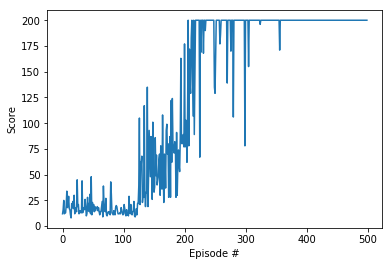

```python
def dqn(n_episodes=500, max_t=1000, eps_start=1.0, eps_end=0.01, eps_decay=0.995):
    """Deep Q-Learning.

    Params
    ======
        n_episodes (int): maximum number of training episodes
        max_t (int): maximum number of timesteps per episode
        eps_start (float): starting value of epsilon, for epsilon-greedy action selection
        eps_end (float): minimum value of epsilon
        eps_decay (float): multiplicative factor (per episode) for decreasing epsilon
    """
    scores = []                        # list containing scores from each episode
    scores_window = deque(maxlen=100)  # last 100 scores
    eps = eps_start                    # initialize epsilon
    for i_episode in range(1, n_episodes+1):
        state = env.reset()
        score = 0
        for t in range(max_t):
            action = agent.act(state, eps)
            next_state, reward, done, _ = env.step(action)
            agent.step(state, action, reward, next_state, done)
            state = next_state
            score += reward
            if done:
                break
        scores_window.append(score)       # save most recent score
        scores.append(score)              # save most recent score
        eps = max(eps_end, eps_decay*eps) # decrease epsilon
        print('\rEpisode {}\tAverage Score: {:.2f}'.format(i_episode, np.mean(scores_window)), end="")
        if i_episode % 100 == 0:
            print('\rEpisode {}\tAverage Score: {:.2f}'.format(i_episode, np.mean(scores_window)))
    return scores

agent = Agent(state_size=4, action_size=2, seed=0)
scores = dqn()
torch.save(agent.qnetwork_local.state_dict(), "checkpoint.pth")

# plot the scores
fig = plt.figure()
ax = fig.add_subplot(111)
plt.plot(np.arange(len(scores)), scores)
plt.ylabel('Score')
plt.xlabel('Episode #')
plt.show()
```

Si votre politique a convergé, vous pouvez à nouveau tester votre solution en image :

[output not shown]

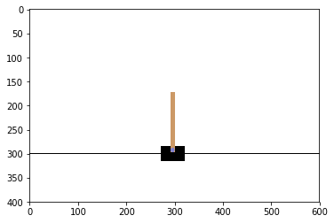

```python
agent.qnetwork_local.load_state_dict(torch.load('checkpoint.pth'))

state = env.reset()
for j in range(50):
    action = agent.act(state)
    state, reward, done, _ = env.step(action)
    plot_screen(env)
    print(done)
    if done:
        break

env.close()
```